# Overview Youth Survey

Julia Rohrer

2026-06-15

These pages contain the analyses code, as well as full analysis results (plus some additional analyses we conducted while building up our models) for the manuscript “Why has the gender gap in life satisfaction among adolescents in Leipzig grown?” by Julia M. Rohrer, Richard McElreath, and Gregor Kachel.

For any questions, please reach out to Julia.

Unfortunately, we cannot share the underlying data; due to legal requirements, these can only be made available by the City of Leipzig and with a special contract.

- Cleaning and preparation of the Youth Surveys
- Reproducing the central explanandum and looking at alternative satisfaction measures
- Initial ordinal analysis: Could this pattern be a scaling artifact?
- Do demographics explain away the widening gender gap?
- Could this pattern result from changes in survey mode?
- Confirming findings with an ordinal model
- Can we explain patterns on alternative satisfaction measures in the same manner?
- Miscellaneous: Checking some additional numbers regarding migration background

### Additional information on the match between target population and our sample

As stated in the manuscript, the City of Leipzig aimed to sample in accordance with the actual distribution of students across the school types and grade levels included. The following plots illustrate the joint distribution of those two variables in the target population of interest (students in Leipzig, attending grade levels 7 to 12 in general secondary and grammar schools) vs. in our sample.

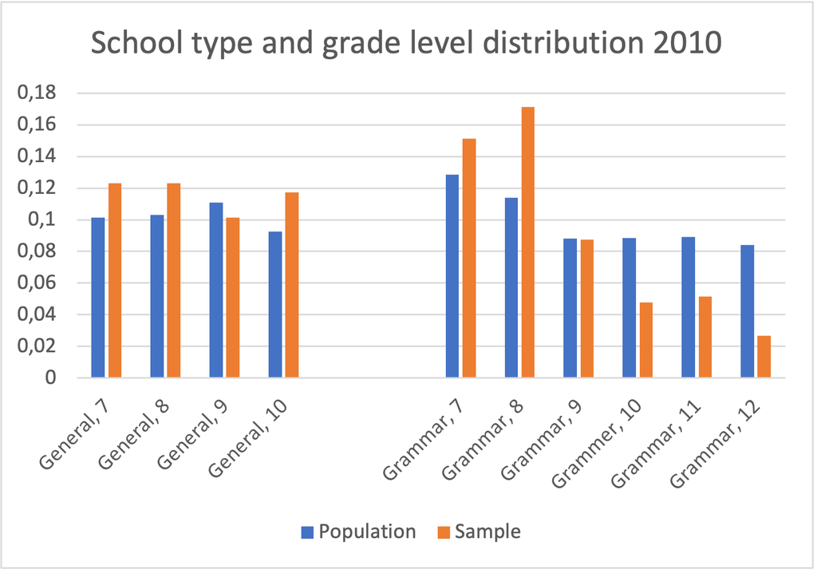

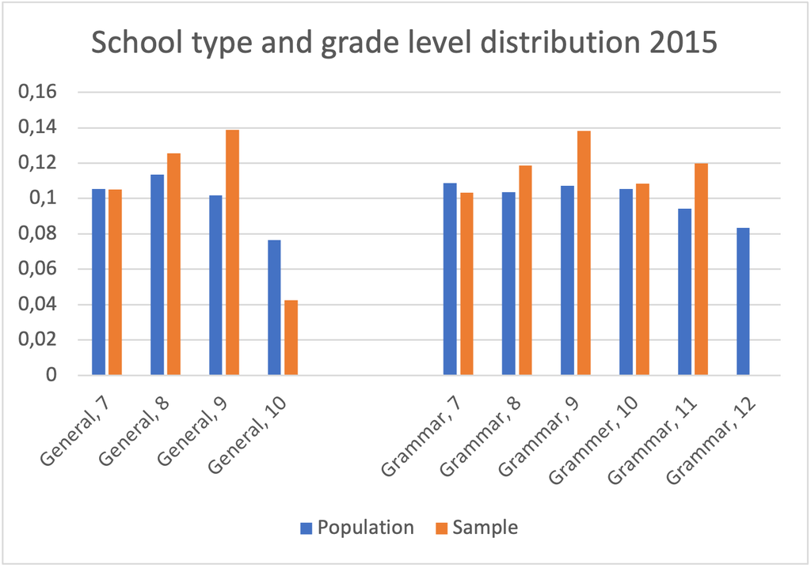

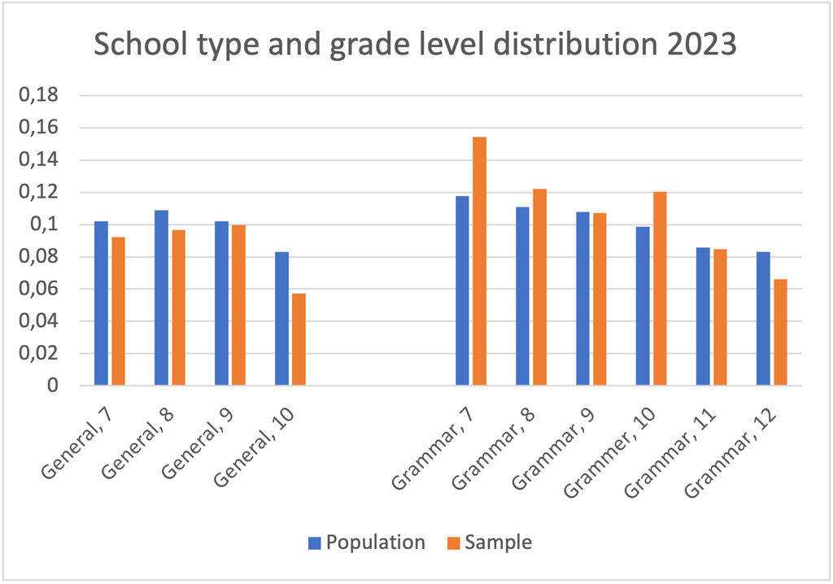

2023 distribution